# Intermediate analyses report - Tits reproduction study, PubPrivLands project (Martin *et al.*, *in prep.*)

# 1. Introduction

## 1.1. Regarding reproductibility

All codes used in this study can furthermore be found here: https://github.com/mrelnoob/ppl.tits

## 1.2. What is this document about?

### 1.2.1. Presentation of the data processing methodology

In the context of the *tits reproduction study* of the PubPrivLands project, we undertook a complex data processing methodology that can be divided into **five stages**:

1. **Raw data acquisition and preparation** - This initial stage consists of all *raw* data acquisition through fieldwork, GIS or remote-sensing-based data generation, and database extractions as well as their initial *cleaning* and *formatting* to produce **raw datasets** (e.g. tits reproduction observations, environmental variables). This stage is globally described in the *Materials & Methods* section of the manuscript, and is thoroughly detailed in the **ppl_log.pdf** document (French only, see Supplementary Materials).
2. **Clean dataset generation** - This stage includes all basic *cleaning*, *wrangling*, *computing* and *formatting* required to obtain a **clean exploitable dataset**. This stage is documented in the `R` files of the `{ppl.tits}` package openly accessible at: https://github.com/mrelnoob/ppl.tits.
3. **Intermediate analyses** - This stage encompasses all analyses performed to enable the landscape scale habitat connectivity modelling for both tits species and compute connectivity metrics using the [Graphab](https://sourcesup.renater.fr/www/graphab/fr/home.html) software (Foltête *et al.*, 2021). Through this stage, the **final dataset** is generated (`ndata_complete`; i.e. the *clean exploitable dataset* completed with *connectivity metrics*). This stage is described in the *Intermediate analyses report* (the present document).
4. **Exploratory Data Analyses** (EDA) - This stage describes all *EDA* and preliminary *assumption checks* made on the *final dataset* that are required to plan proper statistical analyses for hypotheses testing. This stage is described in the *Exploratory data analyses and preparation report*.
5. **Statistical analyses** - This last stage includes all statistical procedures meant to *test* our study hypotheses, *produce results* and *assess their reliability*. This stage is described in the *Statistical analyses report*.

### 1.2.2. Content of this report

This document presents all analyses related to the third stage of our data processing methodology, that is *intermediate analyses* designed to model the landscape scale **habitat connectivity modelling** for Great tits and Blue tits in our study area.

# 2. Local habitat quality modelling

## 2.1. Rationale

In order to model the habitat connectivity of our focal species with the Graphab software (Foltête *et al.*, 2021), we first have to approximate the *quality* of every habitat patches (i.e. patch capacity), hence enabling weighting the nodes of the graph. Usually, this habitat quality is simply approximated by the patch cover area. In this study, we tried to obtained a more meaningful proxy of habitat quality for tits by developing a model predicting the birds’ *clutch size* using local environmental variables only, hence the denomination of “local habitat quality models”, one for each species.  
Provided we could build *reliable* predictive models based on our nestbox data, the idea was to use these models to **interpolate** tits’ potential *clutch size* for all habitat pixels of our landcover map of the study area, and then evaluate the potential accuracy gained from this procedure compared to the simple use of habitat patches cover area for connectivity metrics computation.

## 2.2. Local habitat model for the Great tits (*Parus major*)

### 2.2.1. Model building

We built a Random Forest (RF) regression model (Breiman, 2001) using the `{randomForest}` package (Liaw & Wiener, 2002). We used *clutch size* as a response variable and, as spatial interpolation was our goal, we only considered **spatially continuous variables** as predictors: i.e. *coord_x*, *coord_y*, *noise_m*, *noise_iq*, *built_area*, *open_area*, *soft_manag_area*, *woodyveg_volume*, *woodyveg_sd* (for the meaning of the variables, readers are referred to table **S1**).

As regular RF implementations are known to have robust default hyperparameters, we did *no hyperparameters tuning* and thus grew a forest of 500 regression trees, each one based on a random subset of $p/3$ predictors and $0.632$ bootstrapped samples. Since we performed no model optimisation, we avoided the need for repeated *k*-fold cross validation or similar resampling procedures (Hastie *et al.*, 2009; Harrell, 2015). The model’s performances were evaluated using its *Mean Squared Error* (MSE) and the automatically computed $R^{2}_{oob}$ (i.e. based on the out-of-bag samples). Additionally, we also computed the global variable importance metrics, using the permutation-based method in order to avoid the known bias associated with the Gini-based method (e.g. Strobl *et al.*, 2007).

## 2.3. Local habitat model for the Blue tits (*Cyanistes caeruleus*)

Despite our efforts, we could not obtain reliable results with our Blue tits data, likely because of insufficient sample size. Consequently, we will only model this species habitat connectivity using patches cover area as proxy of *habitat capacity*.

# 3. Connectivity metric exploration

## 3.1. Connectivity metrics for the Great tits (*Parus major*)

### 3.1.1. Univariate exploration

First, we investigated the existence of potential outliers in the metrics:

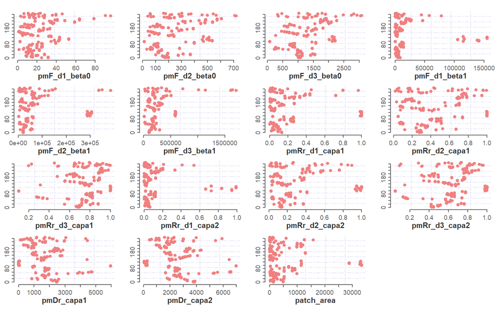

**Figure M3pm.** Cleveland dotplots for all computed F-metrics for *Parus major* nestboxes using AREA as capacity

It appears all *F metrics* have extreme values that may be viewed as outliers even though the situation is less pronounced when *beta* = 0. As expected from the graphical exploration performed on QGIS (not shown here), values of the *d2 capa1 Rr metric* has the nicest distribution among all *Rr* and *Dr metrics*.  
Interestingly, the plots suggest that *Dr metrics* are not just the inverse of the *F*’s.

```r
pm_f$site[which(pm_f$pmF_d2_beta0 > 700)] # To know were the extreme values come from.
```

```
## [1] priv_combe_noyers priv_combe_noyers priv_combe_noyers
## 57 Levels: drapeau pascal_joffre chevreul bd_strasbourg ... priv_neuilly
```

```r
pm_f$site[which(pm_f$pmRr_d1_capa2 > 0.4)]
```

```
##  [1] parc_colombiere   parc_colombiere   parc_colombiere   parc_colombiere
##  [5] parc_colombiere   parc_colombiere   parc_colombiere   parc_colombiere
##  [9] parc_colombiere   parc_colombiere   parc_colombiere   parc_colombiere
## [13] parc_colombiere   parc_colombiere   parc_colombiere   parc_colombiere
## [17] parc_colombiere   parc_colombiere   parc_colombiere   parc_colombiere
## [21] parc_colombiere   parc_colombiere   parc_colombiere   parc_colombiere
## [25] parc_colombiere   parc_colombiere   parc_colombiere   parc_colombiere
## [29] parc_colombiere   priv_combe_noyers priv_combe_noyers priv_combe_noyers
## 57 Levels: drapeau pascal_joffre chevreul bd_strasbourg ... priv_neuilly
```

```r
pm_f$site[which(pm_f$pmDr_capa1 > 3500)]
```

```
##  [1] sq_benedictins    musee_vie_bourg   musee_vie_bourg   republique
##  [5] conseil_regional  conseil_regional  conseil_regional  conseil_regional
##  [9] conseil_regional  carrelet_de_loisy carrelet_de_loisy carrelet_de_loisy
## [13] st_bernard        priv_rue_brulle   priv_chenove
## 57 Levels: drapeau pascal_joffre chevreul bd_strasbourg ... priv_neuilly
```

As expected, most extreme values for *F* and *Rr metrics* are either located in the “Parc de la Colombière” (i.e. the largest urban park of the city, by far, which is also close to the riparian corridor of the Ouche river) or in the “Combe des noyers” (i.e. the residential area located in the forested hillsides on the south-west of the city). Similarly, sites with *Dr_capa1* values > 3500 (i.e. nestboxes from which tits have to move at least 3.5 km [in cost distance] in order to visit enough habitat patches to reach 5000m² of cumulated woody area) are almost all located within the city centre (but not “priv_chenove”).

We then looked at their histograms:

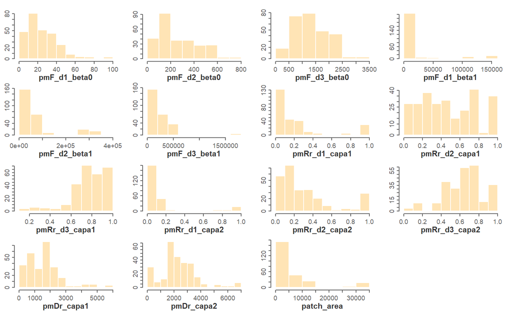

**Figure M4pm.** Histograms for all computed F-metrics for *Parus major* nestboxes using AREA as capacity

We can see that none of the metrics are close to a normal distribution. This might be problematic. Still, some have distributions that might be approximately normalised with a log or a square-root transformation.

### 3.1.2. Multivariate exploration

We then investigated the bivariate correlations among the connectivity metrics and some other predictors (for the sake of visualisation, not all variables are plotted):

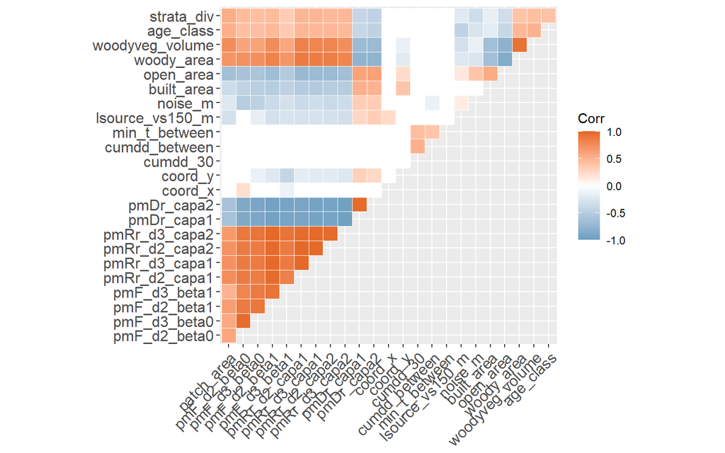

**Figure M5pm.** Correlation matrix displaying *Spearman*’s $\rho$ for all computed F metrics and some selected predictors. Only significant correlations are displayed (with $\alpha$ = 0.05)

Obviously, there are many things to say here:

- First, most predictors are significantly correlated with each others, and all *connectivity metrics* are correlated with each other, suggesting that they share much of the same information. We can also see than, that *patch_area* displays the **same correlation patterns** as the *connectivity metrics*, but with weaker correlations.
- Second, *woody vegetation cover* and *volume* are **strongly positively correlated** with all *connectivity metrics* (or negatively with the *Dr*’s), which was expected but might be problematic for modelling.
- Third, the *F metrics* computed with the **largest distances** are **extremely positively correlated** with each other BUT LESS SO with the other variables, perhaps because the distance is so high that the metric stops being linked to local environmental conditions. We can also see that they are **negatively correlated** with *latitude* displaying the expected **North-South gradient** of connectivity or woody cover (i.e. there are more large woody areas in the south of the city).

To further study distributions and bivariate correlations, we plotted various numeric predictor against each others. It gave us the possibility to start investigating potential **multivariate outliers**.

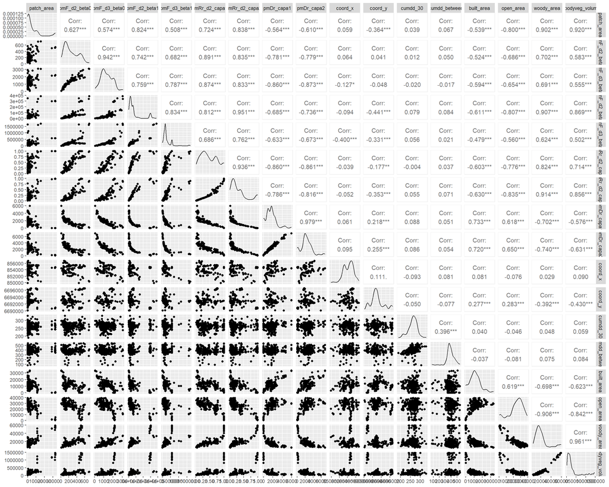

**Figure M6pm.** Bivariate relationship among computed *F-metrics* and some key explanatory variables

This figure emphasizes once more that **the *predictor space* could have been better sampled** as there clearly are some clear **multivariate outliers** (or, at least, extreme values).  
Other interesting observations can be made:

1. *Connectivity metrics* are clearly related to each other, linearly or quadratically.
2. Interestingly, the *Rr* metrics (6-7th rows) do **not** display clear **multivariate outliers**!
3. We can confirm that the connectivity increases with decreasing *built* and *open areas*!
4. The last rows show that the sites with **the highest woody volume** are not necessarily those with **the highest *connectivity metrics*** : i.e. although rank-based correlations are extremely high (particularly for metrics with *beta* = 1), the plot shows **clear bivariate outliers** as well as rather *flat* relationships between these variables! It could mean that the supposedly correlated relationship between **woody vegetation volume** and our **connectivity proxies** may not be so analytically problematic and we could argue that **it legitimises our hypothesis** of an interaction between these two *variables of interest*!

So, up to this point, we’d be rather inclined into retaining the *d2* and/or *capa1*-based connectivity metrics for modelling.

### 3.1.3. Y-based data exploration

To avoid illegitimate data-driven model development, we first started by dividing our dataset into training and testing sets (representing 65% and 35% of the total sample size, respectively).

Then, we looked at simple rank-based bivariate correlations:

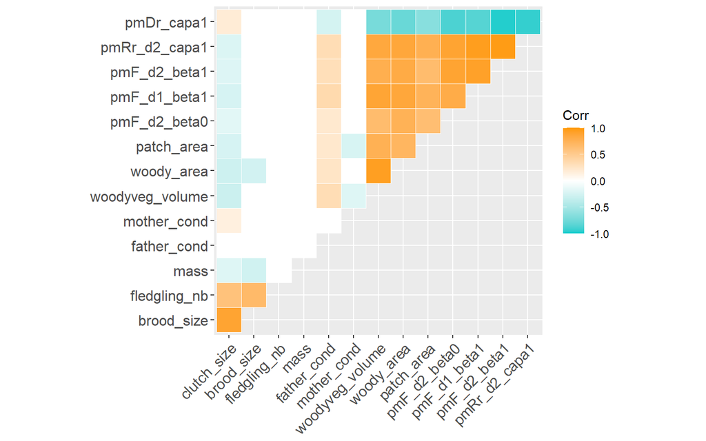

**Figure M7pm.** Correlation matrix displaying *Spearman*’s $\rho$ for all computed F metrics and our response variables on our training set. Only significant correlations are displayed (with $\alpha$ = 0.05)

On this figure, we can see that:

1. Most *response variables* appear **unrelated** to our *F metrics* (according to Spearman’s rank correlations), with the exception of *clutch size* that is **mildly correlated** with all of them. *Clutch size* is also **negatively correlated** with the woody or patch area variables!
2. Surprisingly, the *parental condition variables* (that are covariates) display a very peculiar pattern with *father_cond* being **positively correlated** with our *connectivity metrics* while the reverse is partially true for *mother_cond*.

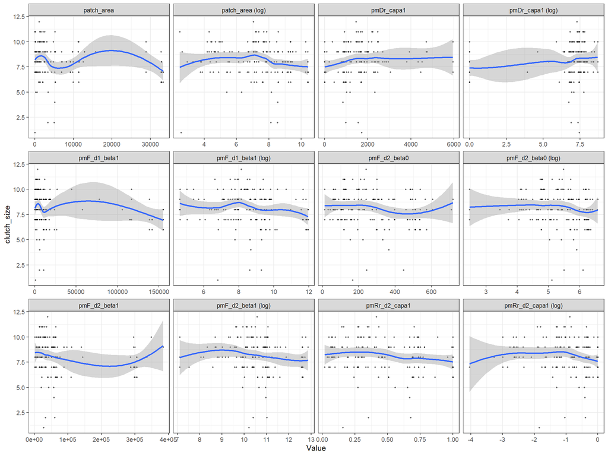

**Figure M8a_pm.** Bivariate scatterplot between *Parus major*’s clutch size and each potential connectivity metric, with and without log-tranformation

We can see that log-transformations could indeed be useful.  
To deepen our grasp of the metrics relevance, we also looked at the relationships with the *mass* of nestlings:

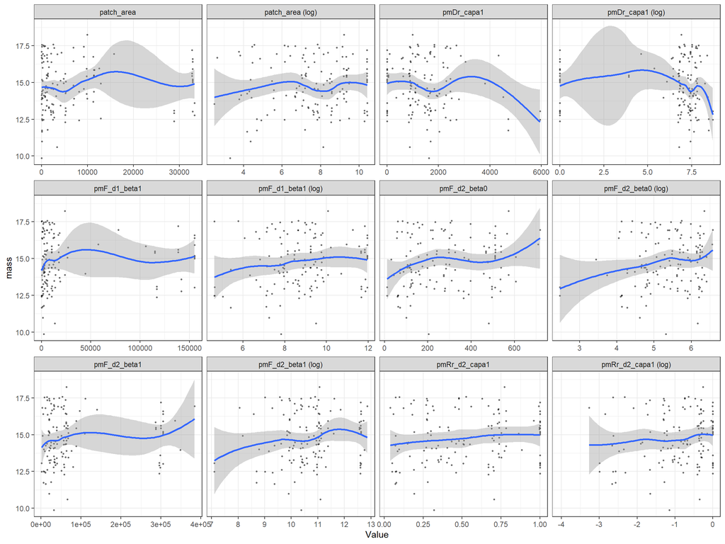

**Figure M8b_pm.** Bivariate scatterplot between the mass of *Parus major* nestlings and each potential connectivity metric, with and without log-tranformation

Same comment as for *clutch_size*.

### 3.1.4. Conclusion

Overall, these observations support our initial preference for the *d2-based* connectivity metrics.

## 3.2. Connectivity metrics for the Blue tits (*Cyanistes caeruleus*)

### 3.2.1. Univariate exploration

Now, we first investigated the existence of potential outliers in the metrics:

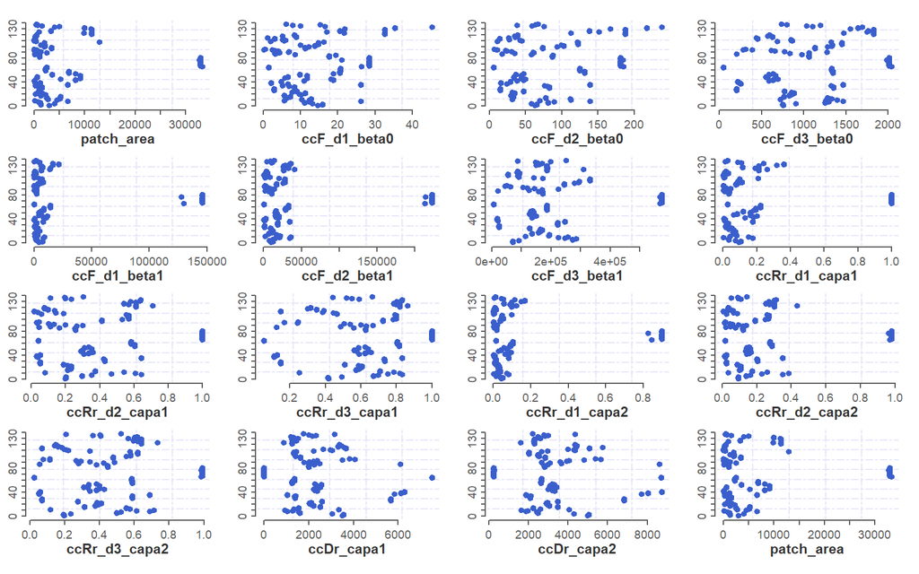

**Figure M3cc.** Cleveland dotplots for all computed F-metrics for *Cyanistes caeruleus* nestboxes using AREA as capacity

It appears all *beta1 F metrics* have extreme values that may be viewed as outliers. Otherwise, same remarks as for *Parus major*.

We then looked at their histograms:

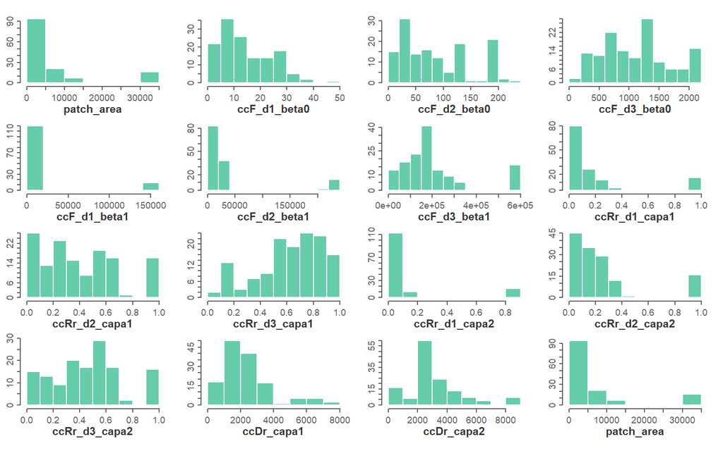

**Figure M4cc.** Histograms for all computed F-metrics for *Cyanistes caeruleus* nestboxes using AREA as capacity

Most metrics are not close to a normal distribution. This might be problematic.

### 3.2.2. Multivariate exploration

We then investigated the bivariate correlations among the *connectivity metrics* and some other predictors:

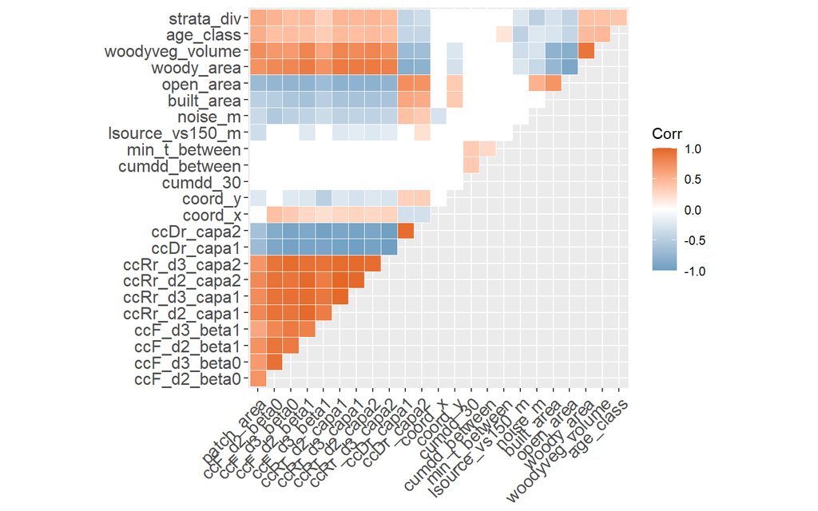

**Figure M5cc.** Correlation matrix displaying *Spearman*’s $\rho$ for all computed F metrics and some selected predictors. Only significant correlations are displayed (with $\alpha$ = 0.05)

Obviously, patterns are quite similar to those observed for *Parus major*:

- First, most predictors are significantly correlated with each others, and most *F or Rr metrics* are **positively correlated** with each other, suggesting that they may carry pretty much the same information.
- Second, *woody vegetation cover* and *volume* are **strongly correlated** with all *connectivity metrics*.

To further study distributions and bivariate correlations, we plotted various numeric predictor against each others. It gave us the possibility to start investigating potential **multivariate outliers**.

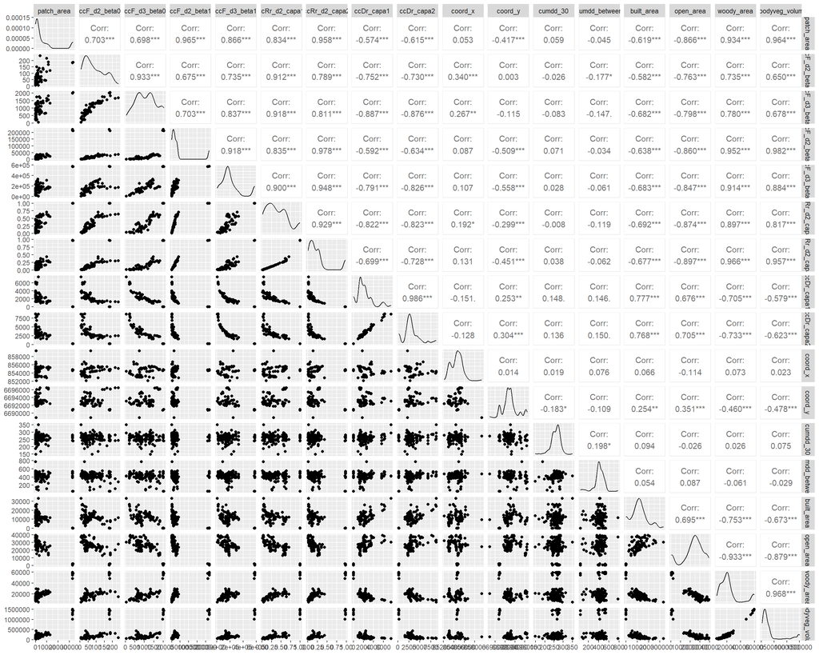

**Figure M6cc.** Bivariate relationship among computed *connectivity metrics* and some key explanatory variables

This figure shows patterns relatively similar with those observed for *Parus major*, but values are sometimes more extreme.

### 3.2.3. Y-based data exploration

To avoid illegitimate data-driven model development, we first started by dividing our dataset into training and testing sets (representing 65% and 35% of the total sample size, respectively).

Then, we looked at simple rank-based bivariate correlations:

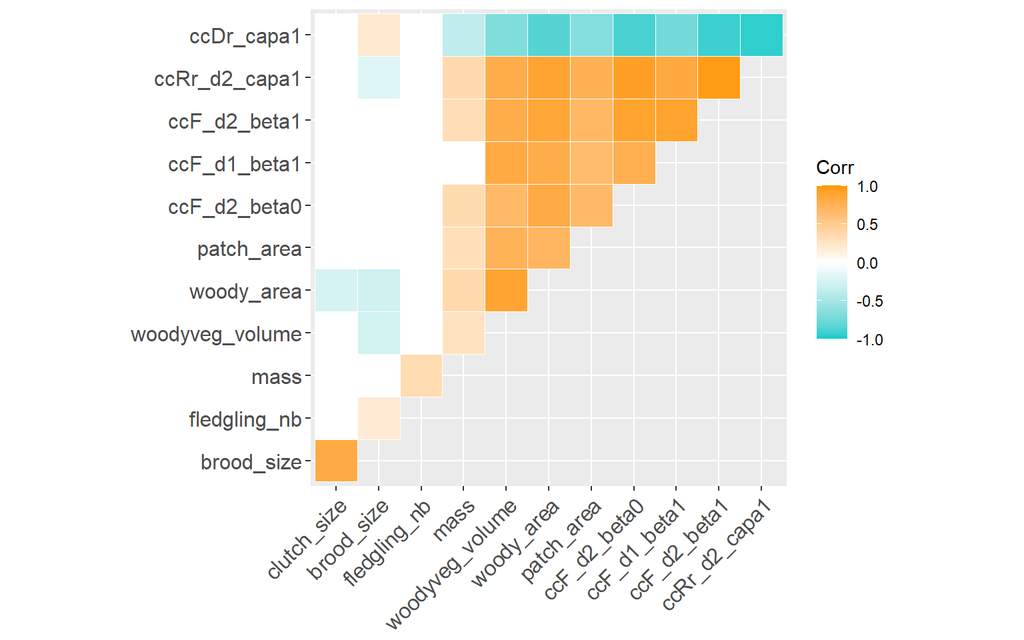

**Figure M7cc.** Correlation matrix displaying *Spearman*’s $\rho$ for all computed F metrics and our response variables on our training set. Only significant correlations are displayed (with $\alpha$ = 0.05)

On this figure, we can see that:

1. Unlike for *Parus major*, several *response variables* appear **correlated** to some *connectivity metrics* (according to Spearman’s rank correlations).
2. Similarly to PM, correlations seem **negative** for the *reproduction related variables* and **positive** for the *morphometric* one.

To further examine these relationships, we plotted the Blue tits couples’ *clutch size* and the *mass* of nestlings against some computed metrics:

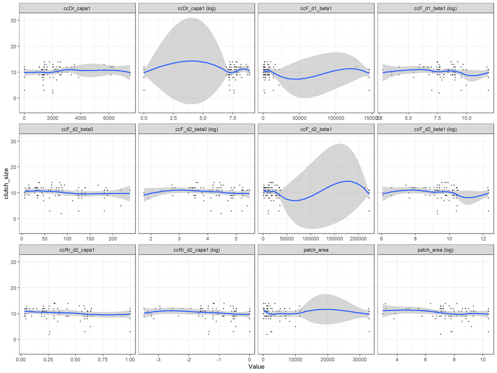

**Figure M8a_cc.** Bivariate scatterplot between *Cyanistes caeruleus*’s clutch size and each potential connectivity metric, with and without log-tranformation

Again, we can see that a log-transformation could be useful for some metrics but definitely not for all of them.

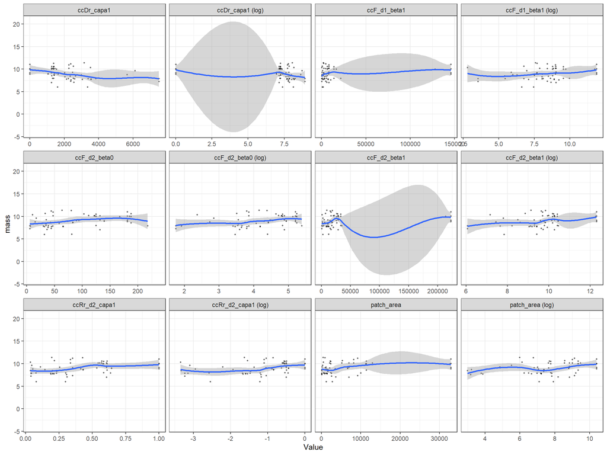

**Figure M8b_cc.** Bivariate scatterplot between the mass of *Cyanistes caeruleus* nestlings and each potential connectivity metric, with and without log-tranformation

Same observation here.

### 3.2.4. Conclusion

Overall, these observations converges with what we saw for *Parus major* and support our decision to select *d2-based* connectivity metrics for inferential modelling.

# 4. References

Breiman L. (2001) ‘Random forests’, *Machine Learning*, 45(1), pp. 5–32. Doi: 10.1023/A:1010933404324.

Foltête J.-C., Vuidel G., Savary P., *et al.* (2021) ‘Graphab: An application for modeling and managing ecological habitat networks’, *Software Impacts*, 8, p. 100065. Doi: 10.1016/j.simpa.2021.100065.

Harrell F. (2015) *Regression modeling strategies. With applications to linear models, logistic and ordinal regression, and survival analysis. Second edition*. Springer: Cham (Switzerland). Available at: https://doi.org/10.1007/978-3-319-19425-7.

Hastie T., Friedman J., & Tibshirani R. (2009) *The elements of statistical learning. Data mining, inference, and prediction. Second edition*. Springer: New York: USA (Springer Series in Statistics). Available at: https://doi.org/10.1007/978-0-387-21606-5.

Liaw A. & Wiener M. (2002) ‘Classification and Regression by randomForest’, *R News*, 2(3), pp. 18–22. Available at: https://CRAN.R-project.org/doc/Rnews/.

Strobl C., Boulesteix A.-L., Zeileis A., *et al.* (2007) ‘Bias in random forest variable importance measures: Illustrations, sources and a solution’, *BMC Bioinformatics*, 8(1), p. 25. Doi: 10.1186/1471-2105-8-25.